# Analysing Personal Movement With A Monitoring Device

Albert Trias

2/20/2021

## Introduction

This is the first assignment of the *Coursera* course **Reproducible Research**. The objectives of this work are:  
- Analyse a dataset with data about personal movement.  
- Learn about **R markdown** and reproducible research.  
- Having a personal template for using it in the future.

## Methodology

As one of the main objectives of this work is to learn how to make reproducible research, and also we would like to have a template for the future, this document include the following steps:

1. Define the question: As more specific better
2. Define the ideal data set
3. Determine what data you can access
4. Obtain the data
5. Clean the data
6. Exploratory data analysis
7. Look at summaries of the data
8. check missing data
9. exploratory plots
10. exploratory analysis (p.e clustering)
11. Statistical predition/modeling
12. Interpret results
13. challenge results
14. Synthesize/write up results
15. Create reproducible code

## Define the question

The question that we would like to address here is if we can deduce some of the activities of an individual over a period of time using the measures of a device like this. Some of the things that we might try to find are the following:  
- Can we deduce at which schedule the device user is sleeping? - Can we know when the user was walking or running? - Can we know if the user has a different routine on weekends?

## Define the ideal data set

We can guess that an ideal dataset for this research would have the data of one year, with the point of view that the user also can take holidays if he is an employed/student and if the current dataset includes a period of time that is to representative in the data it will impact in our data.

About the fields in a dataset the only thing that we need is the number of steps for each interval time. To simplify how the study is done it will by much simpler if these intervals are constant. This interval time can be obtained from two “different variables”, with the date and the *interval*/*timestamp*

## Determine what data you can access

The data that we used for this analysis has been obtained from an [url](https://d396qusza40orc.cloudfront.net/repdata%2Fdata%2Factivity.zip).

Although that it may exist more complete datasets, for this task it is required to use this one, and futhermore using another one would make harder some of the objectives of this work.

## Obtain the data

Before downloading the dataset, we will create the folder structures for the data.

```r
if(!file.exists("./data")) {dir.create(file.path("./", "data"), showWarnings = FALSE)}
if(!file.exists("./data/rawdata")) {dir.create(file.path("./data", "rawdata"),showWarnings = FALSE)}
if(!file.exists("./data/tidydata")) {dir.create(file.path("./data", "tidydata"),showWarnings = FALSE)}
```

Now that we have created the folder structure we proceed downloading the zip file from the provided url, and extracting it in the folder data/rawdata.

```r
datasetUrl<-"https://d396qusza40orc.cloudfront.net/repdata%2Fdata%2Factivity.zip"
zipPath<-"./data/dataactivity.zip"
download.file(datasetUrl,zipPath)
unzip(zipPath,exdir="./data/rawdata")
```

Now we load the dataset, and obtain a few things from it

```r
dataraw<-read.csv("./data/rawdata/activity.csv")
head(dataraw,n=5)
```

```
##   steps       date interval
## 1    NA 2012-10-01        0
## 2    NA 2012-10-01        5
## 3    NA 2012-10-01       10
## 4    NA 2012-10-01       15
## 5    NA 2012-10-01       20
```

```r
tail(dataraw,n=5)
```

```
##       steps       date interval
## 17564    NA 2012-11-30     2335
## 17565    NA 2012-11-30     2340
## 17566    NA 2012-11-30     2345
## 17567    NA 2012-11-30     2350
## 17568    NA 2012-11-30     2355
```

```r
str(dataraw)
```

```
## 'data.frame':    17568 obs. of  3 variables:
##  $ steps   : int  NA NA NA NA NA NA NA NA NA NA ...
##  $ date    : chr  "2012-10-01" "2012-10-01" "2012-10-01" "2012-10-01" ...
##  $ interval: int  0 5 10 15 20 25 30 35 40 45 ...
```

```r
summary(dataraw)
```

```
##      steps            date              interval
##  Min.   :  0.00   Length:17568       Min.   :   0.0
##  1st Qu.:  0.00   Class :character   1st Qu.: 588.8
##  Median :  0.00   Mode  :character   Median :1177.5
##  Mean   : 37.38                      Mean   :1177.5
##  3rd Qu.: 12.00                      3rd Qu.:1766.2
##  Max.   :806.00                      Max.   :2355.0
##  NA's   :2304
```

```r
table(dataraw$steps,useNA="ifany")
```

[output not shown]

[output cut: 82 more lines]

```r
table(dataraw$date,useNA="ifany")
```

```
##
## 2012-10-01 2012-10-02 2012-10-03 2012-10-04 2012-10-05 2012-10-06 2012-10-07
##        288        288        288        288        288        288        288
## 2012-10-08 2012-10-09 2012-10-10 2012-10-11 2012-10-12 2012-10-13 2012-10-14
##        288        288        288        288        288        288        288
## 2012-10-15 2012-10-16 2012-10-17 2012-10-18 2012-10-19 2012-10-20 2012-10-21
##        288        288        288        288        288        288        288
## 2012-10-22 2012-10-23 2012-10-24 2012-10-25 2012-10-26 2012-10-27 2012-10-28
##        288        288        288        288        288        288        288
## 2012-10-29 2012-10-30 2012-10-31 2012-11-01 2012-11-02 2012-11-03 2012-11-04
##        288        288        288        288        288        288        288
## 2012-11-05 2012-11-06 2012-11-07 2012-11-08 2012-11-09 2012-11-10 2012-11-11
##        288        288        288        288        288        288        288
## 2012-11-12 2012-11-13 2012-11-14 2012-11-15 2012-11-16 2012-11-17 2012-11-18
##        288        288        288        288        288        288        288
## 2012-11-19 2012-11-20 2012-11-21 2012-11-22 2012-11-23 2012-11-24 2012-11-25
##        288        288        288        288        288        288        288
## 2012-11-26 2012-11-27 2012-11-28 2012-11-29 2012-11-30
##        288        288        288        288        288
```

```r
table(dataraw$interval,useNA="ifany")
```

```
##
##    0    5   10   15   20   25   30   35   40   45   50   55  100  105  110  115
##   61   61   61   61   61   61   61   61   61   61   61   61   61   61   61   61
##  120  125  130  135  140  145  150  155  200  205  210  215  220  225  230  235
##   61   61   61   61   61   61   61   61   61   61   61   61   61   61   61   61
##  240  245  250  255  300  305  310  315  320  325  330  335  340  345  350  355
##   61   61   61   61   61   61   61   61   61   61   61   61   61   61   61   61
##  400  405  410  415  420  425  430  435  440  445  450  455  500  505  510  515
##   61   61   61   61   61   61   61   61   61   61   61   61   61   61   61   61
##  520  525  530  535  540  545  550  555  600  605  610  615  620  625  630  635
##   61   61   61   61   61   61   61   61   61   61   61   61   61   61   61   61
##  640  645  650  655  700  705  710  715  720  725  730  735  740  745  750  755
##   61   61   61   61   61   61   61   61   61   61   61   61   61   61   61   61
##  800  805  810  815  820  825  830  835  840  845  850  855  900  905  910  915
##   61   61   61   61   61   61   61   61   61   61   61   61   61   61   61   61
```

[output cut: 22 more lines]

```r
table(dataraw[is.na(dataraw$steps),2])
```

```
##
## 2012-10-01 2012-10-08 2012-11-01 2012-11-04 2012-11-09 2012-11-10 2012-11-14
##        288        288        288        288        288        288        288
## 2012-11-30
##        288
```

```r
#we will not create factor variables are all have sense as numeric/data
# data$varname<-factor(data$varname)
```

As we can see there are three dimensions:  
- steps  
- date  
- interval

We will remove the NAs from *steps*

```r
data<-dataraw[!is.na(dataraw$steps),]
data$date<-as.Date(data$date)
summary(data)
```

```
##      steps             date               interval
##  Min.   :  0.00   Min.   :2012-10-02   Min.   :   0.0
##  1st Qu.:  0.00   1st Qu.:2012-10-16   1st Qu.: 588.8
##  Median :  0.00   Median :2012-10-29   Median :1177.5
##  Mean   : 37.38   Mean   :2012-10-30   Mean   :1177.5
##  3rd Qu.: 12.00   3rd Qu.:2012-11-16   3rd Qu.:1766.2
##  Max.   :806.00   Max.   :2012-11-29   Max.   :2355.0
```

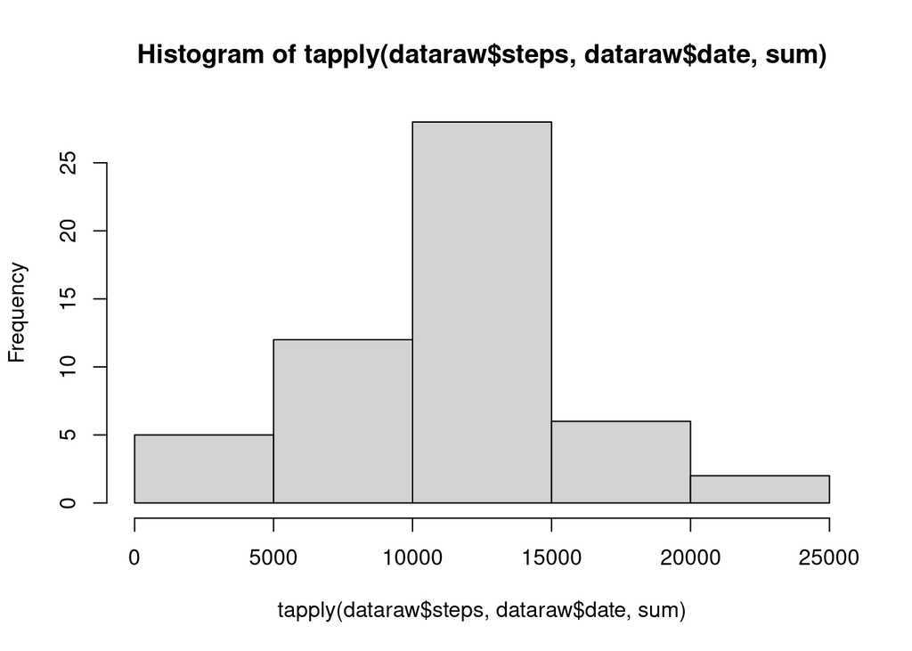

```r
hist(tapply(dataraw$steps,dataraw$date,sum))
```

```r
mean(tapply(data$steps,data$date,sum))
```

```
## [1] 10766.19
```

median

```r
median(tapply(data$steps,data$date,sum))
```

```
## [1] 10765
```

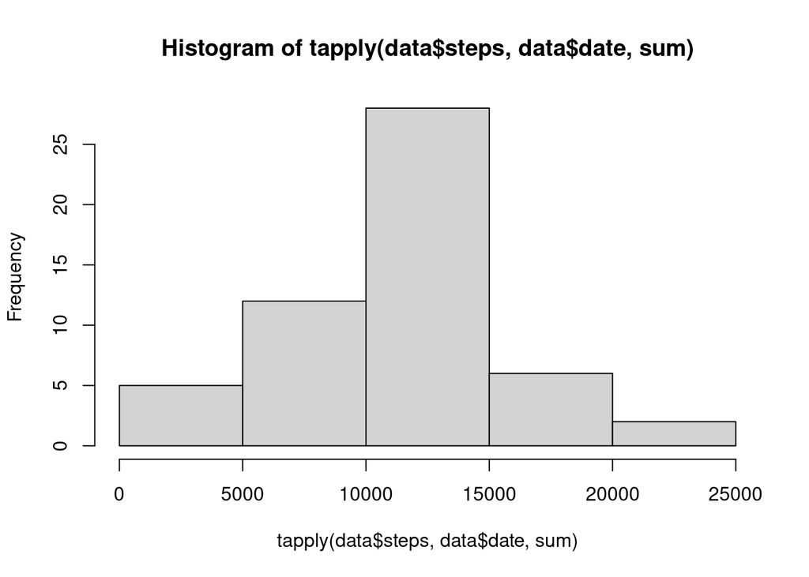

```r
hist(tapply(data$steps,data$date,sum))
```

```r
library(lubridate)
data$isWeekend<-lubridate::wday(data$date) %in% c(1, 7)
table(data$isWeekend)
```

```
##
## FALSE  TRUE
## 11232  4032
```

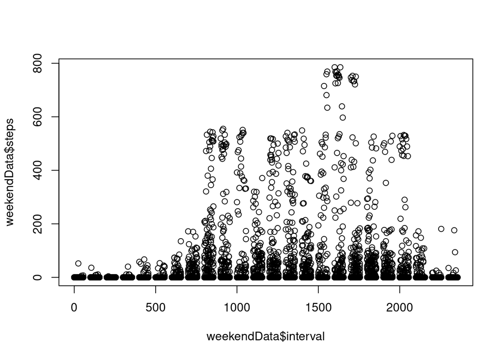

```r
weekendData<-dplyr::filter(data,isWeekend==TRUE)
plot(weekendData$interval,weekendData$steps)
```

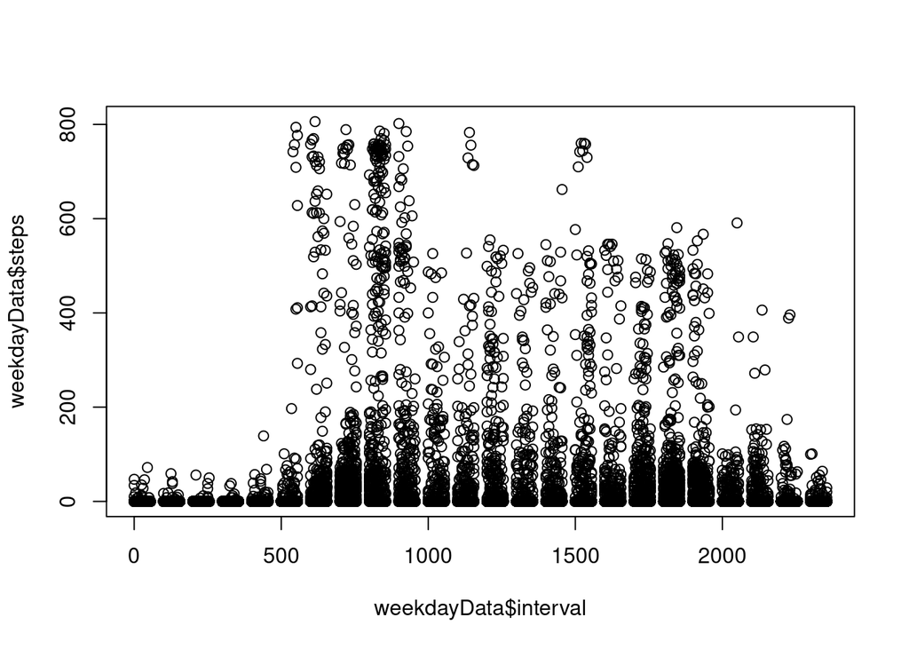

```r
weekdayData<-dplyr::filter(data,isWeekend==FALSE)
plot(weekdayData$interval,weekdayData$steps)
```